# Prediction_pml

YS

8/19/2021

```r
library("knitr")
library("ggplot2")
library("caret")
library("plotly")
library("readr")
library("corrplot")
library("rattle")
library("gridExtra")
```

## Introduction

Using devices such as Jawbone Up, Nike FuelBand, and Fitbit it is now possible to collect a large amount of data about personal activity relatively inexpensively. These type of devices are part of the quantified self movement One thing that people regularly do is quantify how much of a particular activity they do, but they rarely quantify how well they do it. In this project, the goal will be to use data from accelerometers on the belt, forearm, arm, and dumbell of 6 participants. They were asked to perform barbell lifts correctly and incorrectly in 5 different ways.

- exactly according to the specification (Class A)
- throwing the elbows to the front (Class B)
- lifting the dumbbell only halfway (Class C)
- lowering the dumbbell only halfway (Class D)
- throwing the hips to the front (Class E).

## Data explore

### read in data and clean up variable with too many empty entries and low variability.

```r
# read in data
na.str = c("NA","Not Available","NOt available","","#DIV/0!","N/A")
pml_train <-read.csv("pml-training.csv", na.strings = na.str)
pml_test <- read.csv("pml-testing.csv", na.strings = na.str)

#check the precentage of NA in the training data, getting ride of the columns that are too much to impute
NA_col<-colSums(is.na(pml_train)/nrow(pml_train))
NA_rm<-names(NA_col[NA_col>0.5])

pml_train<-pml_train[,!(names(pml_train) %in% NA_rm)]
pml_test<-pml_test[,!(names(pml_test) %in% NA_rm)]

#check the variability of the variable
library(caret)
nsv <- nearZeroVar(pml_train,saveMetrics=TRUE)
pml_train<-pml_train[,nsv$nzv==FALSE]
pml_test<-pml_test[,nsv$nzv==FALSE]

#get rid of columns that not related to movement detection
pml_train<-pml_train[,-c(1:6)]
pml_test<-pml_test[,-c(1:6)]
```

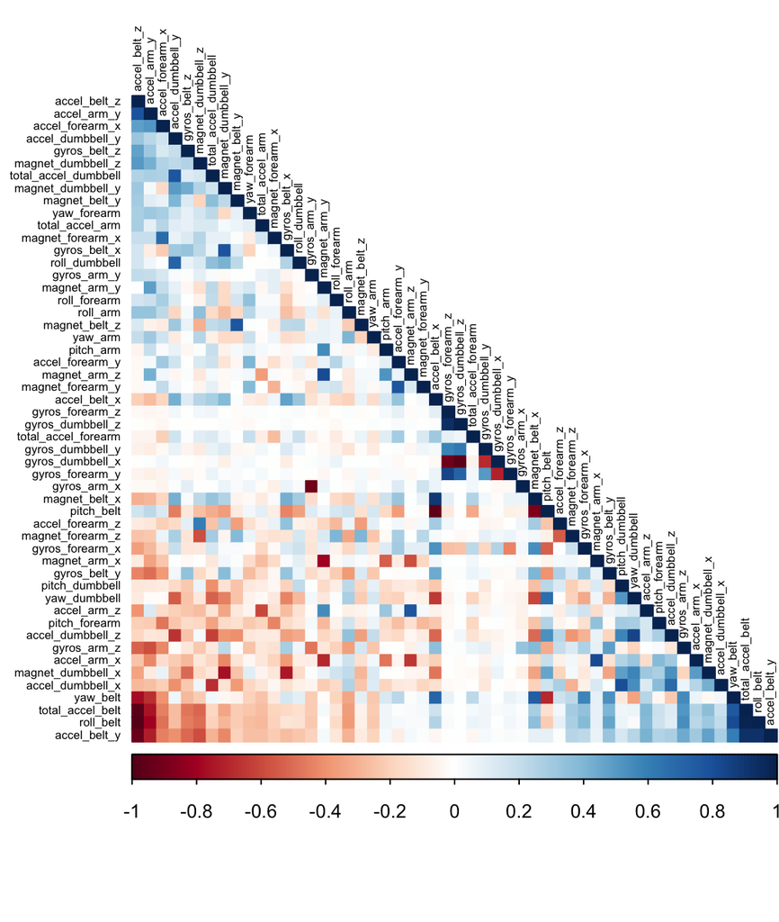

Result:There are some variables that are highly correlated, dataset may need to be pre-processed using “PCA” method

## Data training and prediction

### fitting the training data with different models

```r
#split the training dataset into 2 part, training and testing, save the original testing dataset for validation.
inTrain = createDataPartition(pml_train$classe, p = 3/4)[[1]]
training = pml_train[inTrain,]
testing = pml_train[-inTrain,]

#setup cross validation
trControl=trainControl(method="cv", 5)

#using rpart method for classification training
system.time(
fit_rpart <- train(classe ~ .,method="rpart",trControl=trControl,data = training)
)
```

```
   user  system elapsed
  7.721   0.365   8.145
```

```r
#using rpart method for classification training with pca preprocessing
system.time(
fit_rpart_pca <- train(classe ~ .,method="rpart",trControl=trControl,preProcess="pca",data = training)
)
```

```
   user  system elapsed
  9.231   0.921  10.180
```

```r
#using random forest method for classification training
system.time(
fit_rf <- train(classe ~ .,method="rf",trControl=trControl,data = training,ntree=250)
)
```

```
   user  system elapsed
324.474   4.321 329.296
```

```r
#using random forest method for classification training with pca pre-processing
system.time(
fit_rf_pca <- train(classe ~ .,method="rf",trControl=trControl,preProcess="pca",data = training,ntree=250)
)
```

```
   user  system elapsed
199.700   5.346 205.317
```

### predict with different models

```r
predict_rpart<-predict(fit_rpart,testing)
predict_rpart_pca<-predict(fit_rpart_pca,testing)
predict_rf<-predict(fit_rf,testing)
predict_rf_pca<-predict(fit_rf_pca,testing)
# CM_rpart<-confusionMatrix(as.factor(testing$classe),predict_rpart)
# CM_rpart_pca<-confusionMatrix(as.factor(testing$classe),predict_rpart_pca)
# CM_rf<-confusionMatrix(testing$classe,predict_rf)
# CM_rf_pca<-confusionMatrix(testing$classe,predict_rf_pca)
```

### Comparing Models

```r
cvValues <- resamples(list(rpart = fit_rpart, rpart_pca = fit_rpart_pca,
                           rf = fit_rf, rf_pca = fit_rf_pca))

summary(cvValues)
```

```
Call:
summary.resamples(object = cvValues)

Models: rpart, rpart_pca, rf, rf_pca
Number of resamples: 5

Accuracy
               Min.   1st Qu.    Median      Mean   3rd Qu.      Max. NA's
rpart     0.4954160 0.5013587 0.5049269 0.5060488 0.5137615 0.5147808    0
rpart_pca 0.3283531 0.3325408 0.3379755 0.3601814 0.3963290 0.4057085    0
rf        0.9894737 0.9918478 0.9918478 0.9919151 0.9932019 0.9932042    0
rf_pca    0.9690897 0.9701087 0.9704484 0.9717357 0.9741760 0.9748556    0

Kappa
                Min.    1st Qu.     Median      Mean   3rd Qu.      Max. NA's
rpart     0.34131295 0.34486350 0.35080080 0.3534433 0.3631299 0.3671094    0
rpart_pca 0.07041604 0.07934406 0.08770002 0.1360297 0.2063892 0.2362993    0
rf        0.98668458 0.98968739 0.98968995 0.9897732 0.9913991 0.9914047    0
rf_pca    0.96091084 0.96217147 0.96261061 0.9642411 0.9673197 0.9681930    0
```

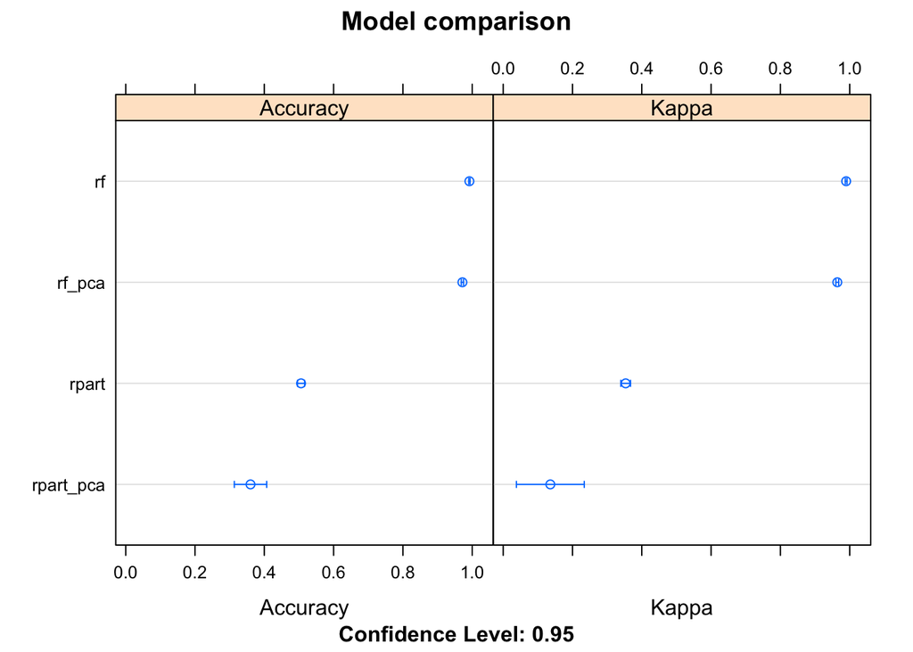

```r
dotplot(cvValues,main = "Model comparison")
```

result:

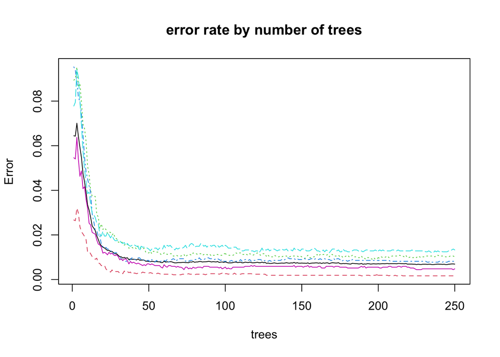

```r
plot(fit_rf$finalModel,main="error rate by number of trees")
```

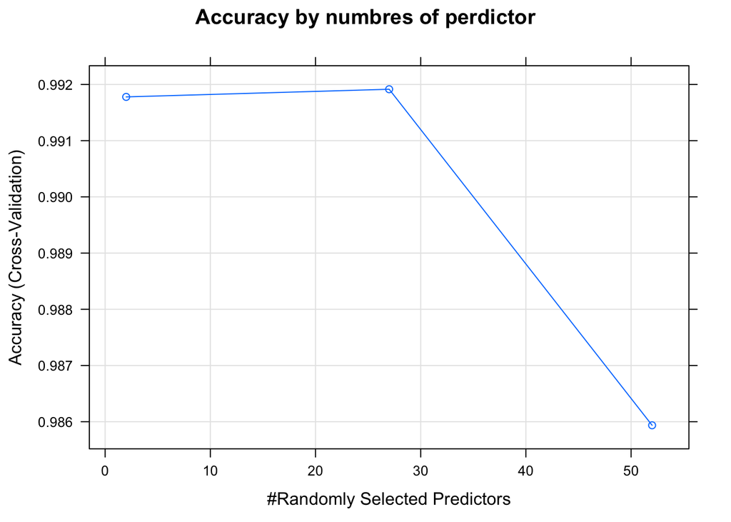

```r
plot(fit_rf,main="Accuracy by numbres of perdictor")
```

```r
varImp(fit_rf, scale = T)
```

```
rf variable importance

  only 20 most important variables shown (out of 52)

                     Overall
roll_belt             100.00
pitch_forearm          58.00
yaw_belt               55.89
pitch_belt             45.42
magnet_dumbbell_z      44.00
roll_forearm           42.05
magnet_dumbbell_y      41.27
accel_dumbbell_y       22.25
roll_dumbbell          18.60
magnet_dumbbell_x      17.93
accel_forearm_x        17.48
magnet_belt_z          14.75
total_accel_dumbbell   13.72
magnet_forearm_z       13.72
accel_dumbbell_z       13.62
accel_belt_z           12.16
magnet_belt_y          12.02
yaw_arm                11.52
gyros_belt_z           10.87
magnet_belt_x          10.02
```

## Final prediction

```r
predict_final<-predict(fit_rf,pml_test)
predict_final
```

```
 [1] B A B A A E D B A A B C B A E E A B B B
Levels: A B C D E
```